# Indian House Price Prediction Project

Authors

Mentor: Urbi Datta

Group members: Atreya Ghoshal, Bighnesh Sahu, Srijita Datta, Sumit Jha, Swarnava Kundu

Published

February 24, 2026

## 1 File description:

The **“India Housing Prices”** dataset contains 2.5 lakhs rows and 23 columns, offering detailed insights into housing market trends across various Indian states. It includes attributes related to - property types, pricing, location, and amenities, making it suitable for analysis ranging from basic descriptive statistics to advanced machine learning applications.

HTML Version of our project: [Indian House Price Prediction Project](https://swarna066.github.io/Indian_House_Pricing_Project/Project.html)

```r
dt = read.csv(file = "D:/MTTS STDSMLAI/Indian_House_Pricing_Project/india_housing_prices.csv",
              header = TRUE)
#head(dt,n=3)
```

```r
dim(dt)
```

```
[1] 250000     23
```

```r
colnames(dt)
```

```
 [1] "ID"                             "State"
 [3] "City"                           "Locality"
 [5] "Property_Type"                  "BHK"
 [7] "Size_in_SqFt"                   "Price_in_Lakhs"
 [9] "Price_per_SqFt"                 "Year_Built"
[11] "Furnished_Status"               "Floor_No"
[13] "Total_Floors"                   "Age_of_Property"
[15] "Nearby_Schools"                 "Nearby_Hospitals"
[17] "Public_Transport_Accessibility" "Parking_Space"
[19] "Security"                       "Amenities"
[21] "Facing"                         "Owner_Type"
[23] "Availability_Status"
```

## 2 Columns in our dataset:

Some preliminary observations of the given dataset:

- **ID**: Different rows having different Integer values.
- **State**: Indian States ( character ).
- **City**: Name of Cities ( character ).
- **Locality**: Name of Localities ( character ).
- **Property_Type**: There are 3 types of properties - Apartment, Independent House, Villa ( character ).
- **BHK**: 5 varieties are there - 1,2,3,4,5 ( integer ).
- **Size_in_sqFt**: Plot size in Sqft ( integer ).
- **Price_in_Lakhs**: Price of the properties in Lakhs ( Double ).
- **Price_per_SqFt**: Price of the properties per Sqft ( Double ).
- **Year_Built**: Year in which the property was built ( integer ).
- **Furnished_Status**: Status of furnishing - Furnished, Unfurnished, Semi-furnished ( character ).
- **Floor_No.**: Floor No. ( Integer ).
- **Total_Floors**: Total no. of floors ( Integer ).
- **Age_of_Property**: Age of the property ( Integer ).
- **Nearby_Schools**: No. of schools nearby ( Integer ).
- **Nearby_Hospitals**: No. of hospitals nearby ( Integer ).
- **Public_Transport_Accessibility**: Ease of accessing public transportation - High, Low, Medium ( character ).
- **Parking_Space**: Availability of Parking space - Yes, No ( character ).
- **Security**: Proper security system - Yes, No ( character ).
- **Amenities**: Amenities like: Playground, Gym, Pool, etc. ( character ).
- **Facing**: Orientation of the house - East, West, South, North ( character ).
- **Owner_Type**: Type of owner - Owner, Builder, Broker ( character ).
- **Availability_Status**: Status of availability - Ready_to_move, Under_construction ( character ).

  To explore the following observations dynamically, you can access our **Interactive Indian House Price Dashboard** https://atreyaghoshal.shinyapps.io/indian_housing_shiny/.

```r
typeof(dt$Availability_Status)
```

```
[1] "character"
```

```r
length(unique(dt$Availability_Status))
```

```
[1] 2
```

```r
summary(dt$Size_in_SqFt)
```

```
   Min. 1st Qu.  Median    Mean 3rd Qu.    Max.
    500    1623    2747    2750    3874    5000
```

```r
summary(dt$Price_in_Lakhs)
```

```
   Min. 1st Qu.  Median    Mean 3rd Qu.    Max.
   10.0   132.6   253.9   254.6   376.9   500.0
```

- Size in square foot varies from 500 ft. to 5000 ft. with mean 2750 ft.
- Price in lakhs varies from 10 lakhs to 500 lakhs with mean 254.6 lakhs.

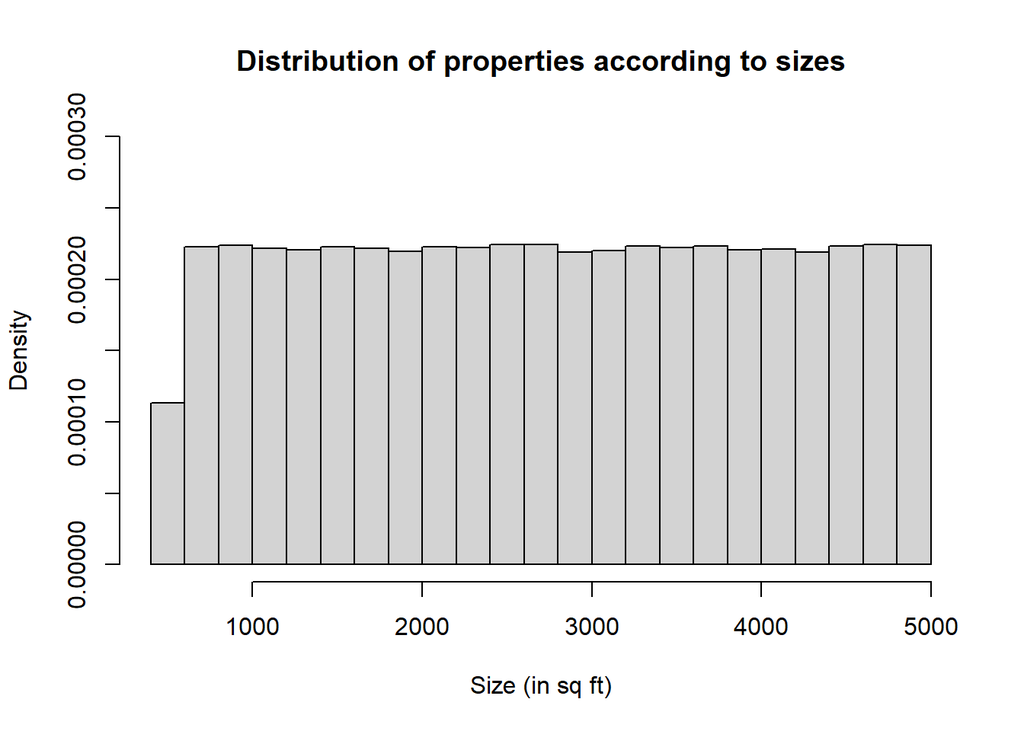

```r
hist(dt$Size_in_SqFt, breaks = 30,probability = TRUE,
       main="Distribution of properties according to sizes",
     xlab="Size (in sq ft)", ylim= c(0,0.00030))
```

```r
summary(dt$Price_in_Lakhs)
```

```
   Min. 1st Qu.  Median    Mean 3rd Qu.    Max.
   10.0   132.6   253.9   254.6   376.9   500.0
```

```r
val = dt$Price_in_Lakhs/10
summary(val)
```

```
   Min. 1st Qu.  Median    Mean 3rd Qu.    Max.
   1.00   13.26   25.39   25.46   37.69   50.00
```

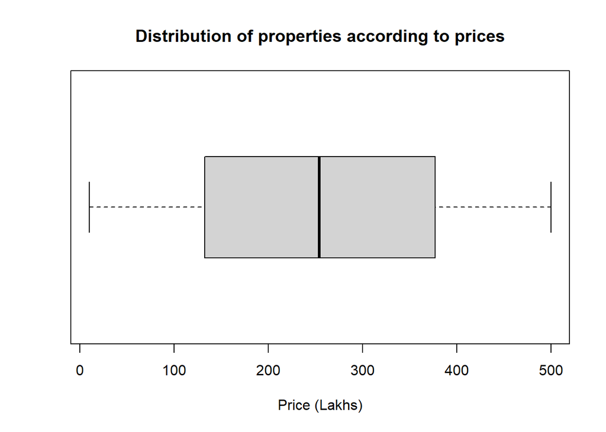

```r
boxplot(dt$Price_in_Lakhs,horizontal = TRUE,
        main = "Distribution of properties according to prices",
        xlab = "Price (Lakhs)")
```

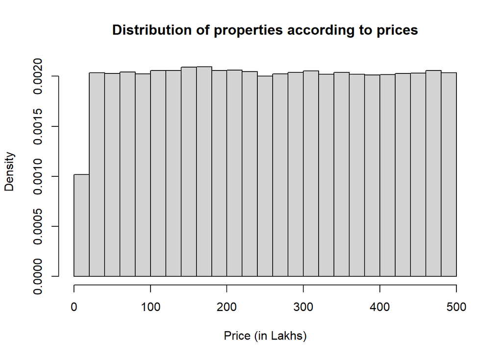

```r
hist(dt$Price_in_Lakhs, breaks = 20,probability = TRUE,
       main="Distribution of properties according to prices",
     xlab="Price (in Lakhs)")
```

```r
summary(dt$Price_per_SqFt)
```

```
   Min. 1st Qu.  Median    Mean 3rd Qu.    Max.
 0.0000  0.0500  0.0900  0.1306  0.1600  0.9900
```

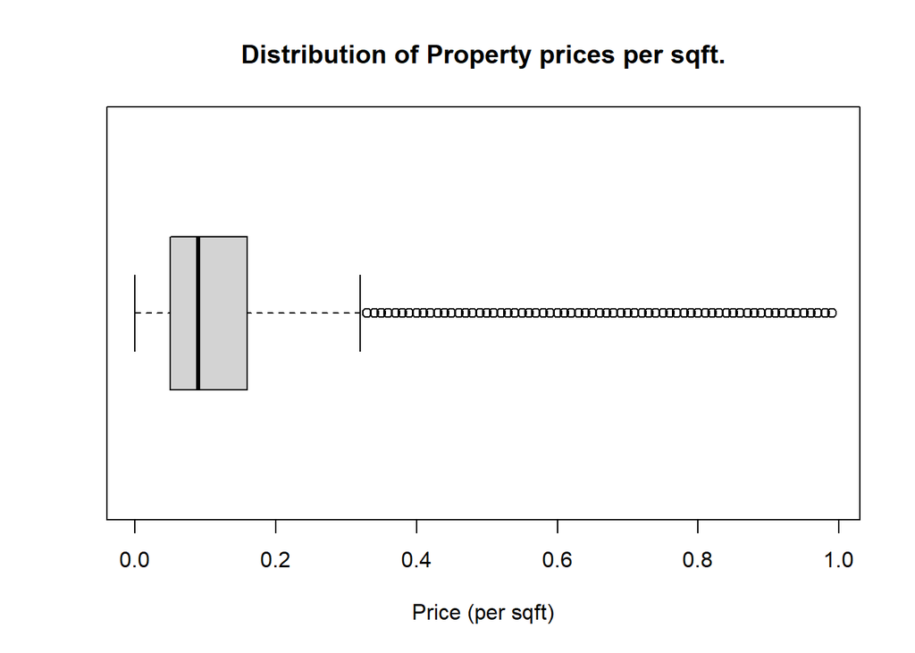

```r
boxplot(dt$Price_per_SqFt,horizontal = TRUE,
        main = "Distribution of Property prices per sqft.",
        xlab = "Price (per sqft)")
```

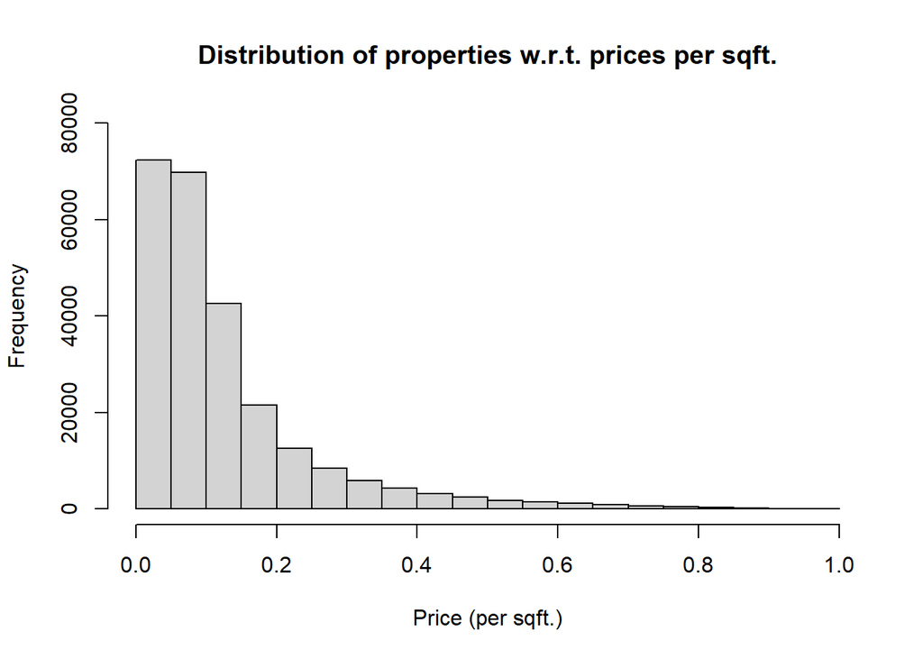

```r
hist( dt$Price_per_SqFt, breaks = 30,
    main="Distribution of properties w.r.t. prices per sqft.",
    xlab="Price (per sqft.)", ylim= c(0,80000))
```

- The data is **positively skewed (right-skewed).**
- The majority of the properties are clustered at the lower end of the price scale (between 0.0 and 0.2).
- Here, a long tail is extending towards the right. This indicates that while most properties are relatively affordable (according to this scale), there are a few properties with significantly higher prices per square foot.

## 3 Observations from the data

### 3.1 Pricing

- **Price_in_Lakhs = Size_in_SqFt × Price_per_SqFt** + (Some dynamic charge/ discount )

```r
Price_diff <- dt$Price_in_Lakhs - (dt$Size_in_SqFt * dt$Price_per_SqFt)
typeof(dt$Size_in_SqFt)
```

```
[1] "integer"
```

```r
pos_price_diff = sum(round(Price_diff,4) > 0.0)
no_price_diff = sum(round(Price_diff,2) == 0.0)
neg_price_diff = sum(round(Price_diff,4) < 0.0)
print((pos_price_diff+no_price_diff+neg_price_diff))
```

```
[1] 250000
```

50.29% of the data has prices greater than the equation.

49.65% of the data has prices less than the equation.

0.05% of the data has exactly same value as the equation.

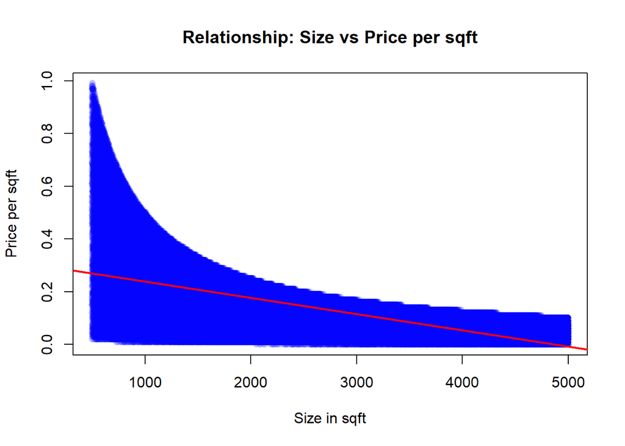

```r
# Predicting the rate (Price per SqFt) instead of total price
rate_model <- lm(Price_per_SqFt ~ Size_in_SqFt, data = dt)

# Plotting the relationship
plot(dt$Size_in_SqFt, dt$Price_per_SqFt,
     pch = 16, col = rgb(0,0,1,0.1),
     main = "Relationship: Size vs Price per sqft",
     xlab = "Size in sqft", ylab = "Price per sqft")
abline(rate_model, col = "red", lwd = 2)
```

- The plot displays a **strong negative non-linear relationship**, where the price per square foot drops sharply as property size increases before stabilizing for larger homes.

### 3.2 Locality

```r
library(dplyr)
locality_summary <- dt %>%
  group_by(City) %>%
  summarize(
    localities = paste(unique(Locality), collapse = ", "),
    no_localities = length(unique(Locality))
  )
print(head(locality_summary,5))
```

```
# A tibble: 5 × 3
  City        localities                                           no_localities
  <chr>       <chr>                                                        <int>
1 Ahmedabad   Locality_74, Locality_387, Locality_382, Locality_4…           500
2 Amritsar    Locality_466, Locality_372, Locality_145, Locality_…           500
3 Bangalore   Locality_462, Locality_125, Locality_498, Locality_…           500
4 Bhopal      Locality_305, Locality_412, Locality_121, Locality_…           500
5 Bhubaneswar Locality_120, Locality_491, Locality_350, Locality_…           500
```

After grouping by state and city, by checking randomly, we see that Locality_463 is present in Ahmedabad and Bhopal.

Now we do a quick search to find in which cities it is present.

```r
dt %>%
  filter(Locality == "Locality_463") %>%
  distinct(City)
```

```
             City
1          Bhopal
2       Ahmedabad
3          Jaipur
4       Hyderabad
5         Silchar
6          Mysore
7      Jamshedpur
8        Guwahati
9  Vishakhapatnam
10       Dehradun
11       Bilaspur
12     Coimbatore
13       Durgapur
14     Vijayawada
```

[output cut: 28 more lines]

- We find that this locality is present in all of the 42 cities.
- **Each city has 500 localities .**

```r
length(unique(dt$Locality))
```

```
[1] 500
```

- There are 500 localities in total and we observe that all 500 localities are common in all the cities.

### 3.3 Year Built

```r
length(unique(sort(dt$Year_Built)))
```

```
[1] 34
```

```r
summary(dt$Year_Built)
```

```
   Min. 1st Qu.  Median    Mean 3rd Qu.    Max.
   1990    1998    2007    2007    2015    2023
```

- We have properties built between 1990 to 2023.

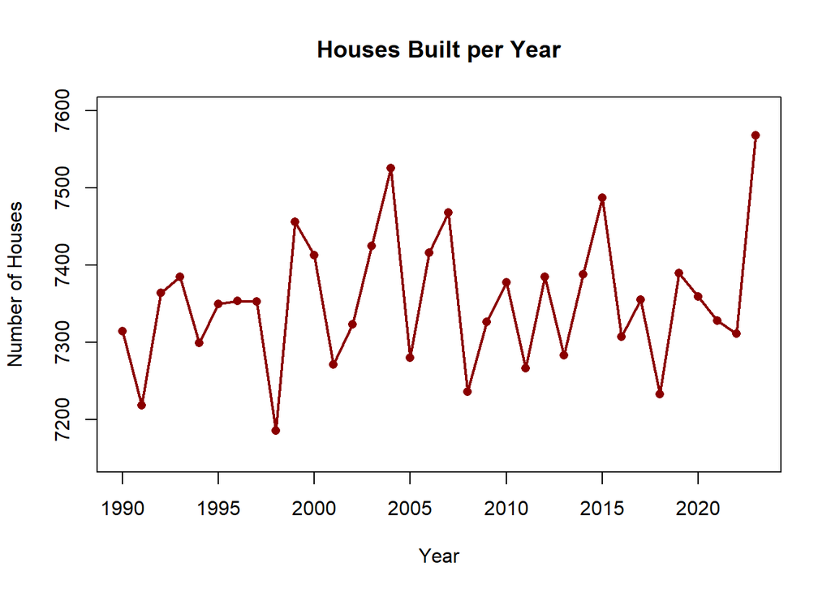

```r
# Count houses per year
yearly_counts <- table(dt$Year_Built)
years <- as.numeric(names(yearly_counts))
counts <- as.vector(yearly_counts)


plot(years, counts,
     type = "o", col = "darkred",pch = 16, lwd = 2,
     main = "Houses Built per Year",xlab = "Year",ylab = "Number of Houses",
     ylim = c(7150,7600))
```

### 3.4 BHK

This section examines the distribution of BHK configurations to identify the most frequently occurring housing type in the dataset.

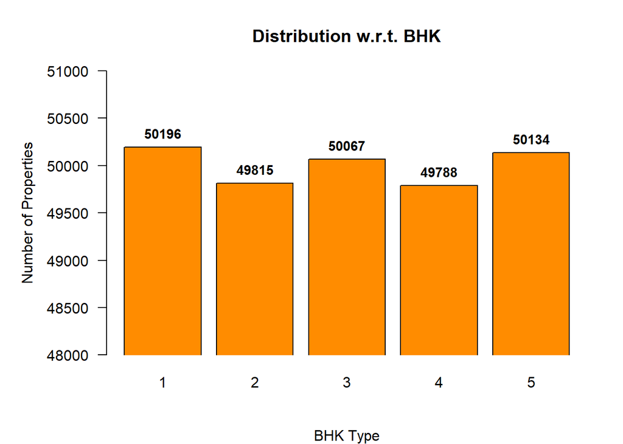

```r
bhk_dist <- table(dt$BHK)

par(mar = c(5, 6, 4, 2),mgp = c(4, 1, 0))
bp <- barplot(bhk_dist, main = "Distribution w.r.t. BHK", xlab = "BHK Type",
              ylab = "Number of Properties",
              col = "darkorange",ylim = c(48000, 51000),xpd = FALSE, border = "black",las = 1)


text(x = bp,y = bhk_dist,label = bhk_dist,pos = 3, cex = 0.9, font = 2,xpd = TRUE)
```

```r
most_common_bhk <- names(which.max(bhk_dist))
most_common_bhk
```

```
[1] "1"
```

- The results indicate that the most common BHK configuration in the dataset is **1 BHK**.

### 3.5 Property

```r
#Counting of properties each cities have
Property_list = dt %>%
  group_by(City) %>%
  summarise(count_prop = length(unique(ID)))
head(Property_list,5)
```

```
# A tibble: 5 × 2
  City        count_prop
  <chr>            <int>
1 Ahmedabad         6411
2 Amritsar          6221
3 Bangalore         4144
4 Bhopal            6284
5 Bhubaneswar       6323
```

```r
Property_list$City[which.max(Property_list$count_prop)]
```

```
[1] "Coimbatore"
```

- So, **Coimbatore** has maximum properties.

```r
# Property type wise average price
Price_per_prop= aggregate(Price_in_Lakhs ~ Property_Type + Availability_Status, data = dt, FUN = mean)
Price_per_prop
```

```
      Property_Type Availability_Status Price_in_Lakhs
1         Apartment       Ready_to_Move       254.9925
2 Independent House       Ready_to_Move       255.8287
3             Villa       Ready_to_Move       254.1354
4         Apartment  Under_Construction       254.2484
5 Independent House  Under_Construction       254.9224
6             Villa  Under_Construction       253.4039
```

```r
# Property type wise average price per sqft
Price_per_sqft_prop= aggregate(Price_per_SqFt ~ Property_Type + Availability_Status, data = dt, FUN = median)
Price_per_sqft_prop
```

```
      Property_Type Availability_Status Price_per_SqFt
1         Apartment       Ready_to_Move           0.09
2 Independent House       Ready_to_Move           0.09
3             Villa       Ready_to_Move           0.09
4         Apartment  Under_Construction           0.09
5 Independent House  Under_Construction           0.09
6             Villa  Under_Construction           0.09
```

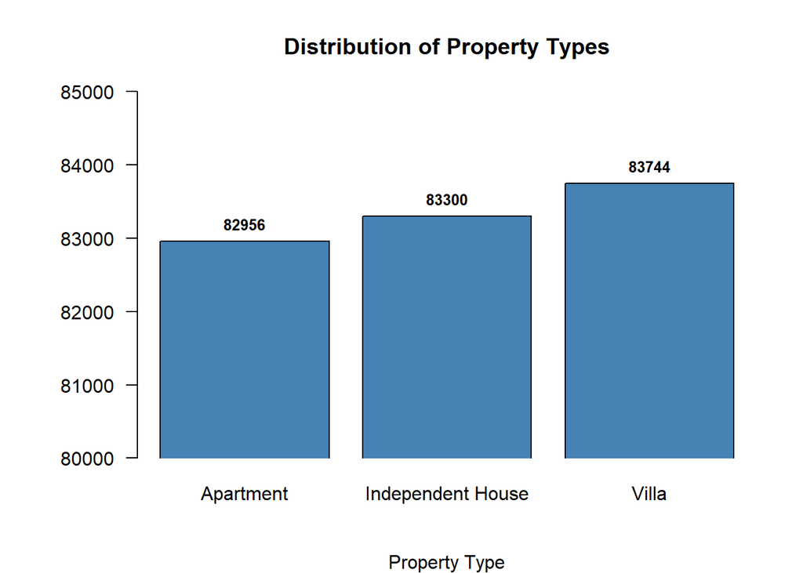

```r
property_type_dist <- table(dt$Property_Type)


par(mar = c(5, 6, 4, 2),mgp = c(4, 1, 0))

bp = barplot(property_type_dist,
        main = "Distribution of Property Types",
        xlab = "Property Type",
        col = "steelblue",xpd = FALSE, ylim = c(80000,85000),
        las = 1)

text(x = bp,
     y = property_type_dist,
     labels = property_type_dist,
     pos = 3, xpd = FALSE,
     cex = 0.8,
     font = 2)
```

### 3.6 Impact of Public Transport Accessibility on Property Prices

```r
pt_price <- aggregate(
  Price_in_Lakhs ~ Public_Transport_Accessibility,
  data = dt,
  median
)

pt_price
```

```
  Public_Transport_Accessibility Price_in_Lakhs
1                           High         254.71
2                            Low         254.27
3                         Medium         252.73
```

- The accessibility of public transport has minimal effect on prices.

### 3.7 Furnished vs Unfurnished Property Prices

```r
furnish_price <- aggregate(
  Price_in_Lakhs ~ Furnished_Status,
  data = dt,median
)

furnish_price
```

```
  Furnished_Status Price_in_Lakhs
1        Furnished        253.555
2   Semi-furnished        253.810
3      Unfurnished        254.190
```

- According to the data the furnishing status has minimal effect on prices.

### 3.8 Year Wise Price Change Analysis

```r
data_1990 = dt[dt$Year_Built == 1990,]
summary(data_1990$Price_in_Lakhs)
```

```
   Min. 1st Qu.  Median    Mean 3rd Qu.    Max.
  10.17  134.41  253.09  255.83  379.80  499.50
```

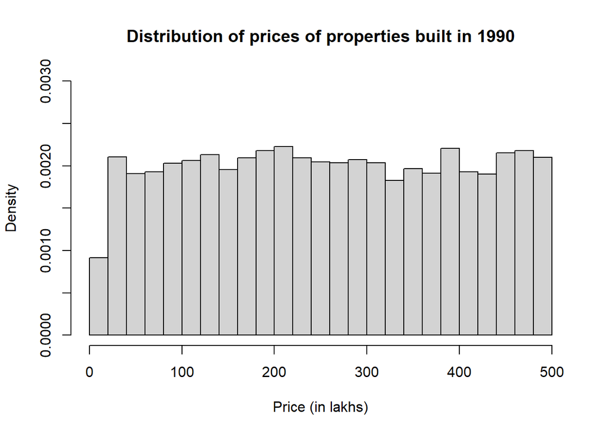

```r
hist(data_1990$Price_in_Lakhs,breaks = 30,probability = TRUE,
     main="Distribution of prices of properties built in 1990",
    xlab="Price (in lakhs)", ylim= c(0,0.0030))
```

```r
data_1991 = dt[dt$Year_Built == 1991,]
summary(data_1991$Price_in_Lakhs)
```

```
   Min. 1st Qu.  Median    Mean 3rd Qu.    Max.
  10.01  129.83  248.38  251.39  374.07  499.98
```

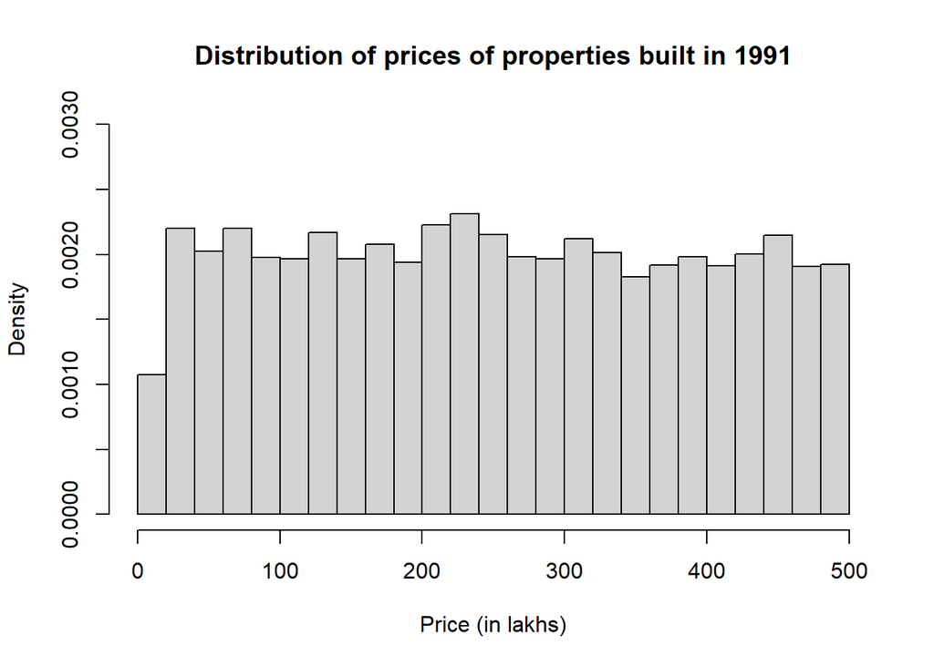

```r
hist(data_1991$Price_in_Lakhs,breaks = 30,probability = TRUE,
     main="Distribution of prices of properties built in 1991",
    xlab="Price (in lakhs)" , ylim= c(0,0.0030))
```

- The summary of prices for these two years are similar.

```r
# Calculate the yearly statistics
yearly_mean <- aggregate(Price_in_Lakhs ~ Year_Built, data = dt, FUN = mean)
yearly_min  <- aggregate(Price_in_Lakhs ~ Year_Built, data = dt, FUN = min)
yearly_max  <- aggregate(Price_in_Lakhs ~ Year_Built, data = dt, FUN = max)
yearly_median <- aggregate(Price_in_Lakhs ~ Year_Built, data = dt, FUN = median)
```

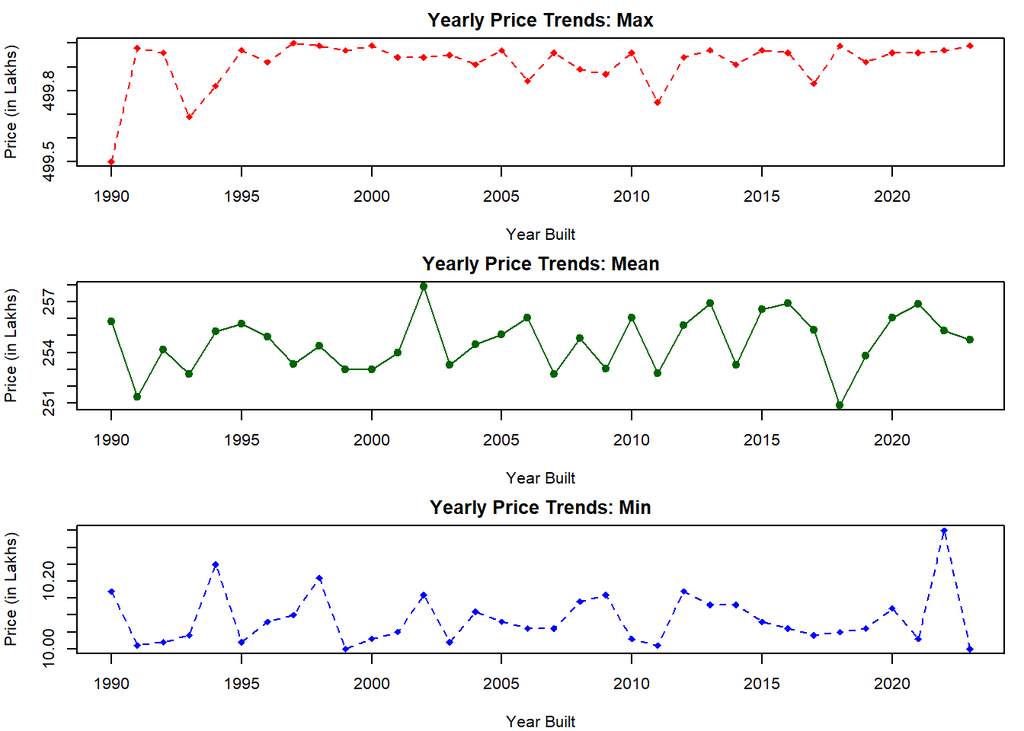

  ```r
  par(mfrow = c(3, 1), mar = c(4, 4, 2, 1))
  # initial plot with the Max (red)
  plot(x = yearly_max$Year_Built, yearly_max$Price_in_Lakhs,
        type = "o", col = "red", lty = 2, pch = 18,
        xlab = "Year Built",
       ylab = "Price (in Lakhs)",
       main = "Yearly Price Trends: Max")

  # mean line
  plot(yearly_mean$Year_Built, yearly_mean$Price_in_Lakhs,
       type = "o",
       pch = 19,
       col = "darkgreen",
       xlab = "Year Built",
       ylab = "Price (in Lakhs)",
       main = "Yearly Price Trends: Mean")

  # Minimum line (Dashed blue)
  plot(yearly_min$Year_Built, yearly_min$Price_in_Lakhs,
        type = "o", col = "blue", lty = 2, pch = 18,
        xlab = "Year Built",
       ylab = "Price (in Lakhs)",
       main = "Yearly Price Trends: Min")
  ```

- The mean price fluctuates within a very narrow band (roughly between **251 and 257 Lakhs**). This tells us that despite individual year-to-year variations, the house prices didn’t change drastically over the years.

```r
#For Ready_to_Move House
yearly_mean_ready <- aggregate(Price_in_Lakhs ~ Year_Built,data =
                                 dt[which(dt$Availability_Status  =="Ready_to_Move"), ], FUN = mean)

#For Under_Construction House
yearly_mean_cons <- aggregate(Price_in_Lakhs ~ Year_Built,data =
                                 dt[which(dt$Availability_Status  =="Under_Construction"), ], FUN = mean)

library(plotly)

p <- plot_ly() %>%
  # Line for Ready to Move
  add_trace(data = yearly_mean_ready, x = ~Year_Built, y = ~Price_in_Lakhs, name = 'Ready_to_Move',
            type = 'scatter', mode = 'lines+markers', line = list(color = 'darkgreen')) %>%

  # Line for Under Construction
  add_trace(data = yearly_mean_cons, x = ~Year_Built, y = ~Price_in_Lakhs, name = 'Under_Construction',
            type = 'scatter', mode = 'lines+markers', line = list(color = 'blue', dash = 'dash')) %>%

  # Line for Overall Median
  add_trace(data = yearly_mean, x = ~Year_Built, y = ~Price_in_Lakhs, name = 'Overall Mean',
            type = 'scatter', mode = 'lines+markers', line = list(color = 'red', dash = 'dash')) %>%

  # Layout and Axis Titles
  layout(title = "Built-Year wise Mean Price Trends: Ready_to_Move vs Under_Construction",
         xaxis = list(title = "Year Built"),
         yaxis = list(title = "Price (in lakhs)", range = c(240, 270)),
         hovermode = "x unified") # Shows all values when hover over a year

# Display the plot
p
```

[interactive chart not shown]

```r
### Calculation for median
yearly_median_ready <- aggregate(Price_in_Lakhs ~ Year_Built,data =
                                 dt[which(dt$Availability_Status  =="Ready_to_Move"), ], FUN = median)

#For Under_Construction House
yearly_median_cons <- aggregate(Price_in_Lakhs ~ Year_Built,data =
                                 dt[which(dt$Availability_Status  =="Under_Construction"), ], FUN = median)


p1 <- plot_ly() %>%
  # Line for Ready to Move
  add_trace(data = yearly_median_ready, x = ~Year_Built, y = ~Price_in_Lakhs, name = 'Ready_to_Move',
            type = 'scatter', mode = 'lines+markers', line = list(color = 'darkgreen')) %>%

  # Line for Under Construction
  add_trace(data = yearly_median_cons, x = ~Year_Built, y = ~Price_in_Lakhs, name = 'Under_Construction',
            type = 'scatter', mode = 'lines+markers', line = list(color = 'blue', dash = 'dash')) %>%

  # Line for Overall Median
  add_trace(data = yearly_median, x = ~Year_Built, y = ~Price_in_Lakhs, name = 'Overall Median',
            type = 'scatter', mode = 'lines+markers', line = list(color = 'red', dash = 'dash')) %>%

  # Layout and Axis Titles
  layout(title = "Built-Year wise Median Price Trends:<br>Ready_to_Move vs Under_Construction",
         xaxis = list(title = "Year Built"),
         yaxis = list(title = "Price (in Lakhs)", range = c(240, 270)),
         hovermode = "x unified") # Shows all values when hover over a year

# Display the plot
p1
```

[interactive chart not shown]

```r
### Calculation for Median
yearly_median_sqft_ready <- aggregate(Price_per_SqFt ~ Year_Built,data =
                                 dt[which(dt$Availability_Status  =="Ready_to_Move"), ], FUN = median)

#For Under_Construction House
yearly_median_sqft_cons <- aggregate(Price_per_SqFt ~ Year_Built,data =
                                 dt[which(dt$Availability_Status  =="Under_Construction"), ], FUN = median)

#For Median Price line
yearly_median_sqft <- aggregate(Price_per_SqFt ~ Year_Built, data = dt, FUN = median)


p2 <- plot_ly() %>%
  # Line for Ready to Move
  add_trace(data = yearly_median_sqft_ready, x = ~Year_Built, y = ~Price_per_SqFt, name = 'Ready_to_Move',
            type = 'scatter', mode = 'lines+markers', line = list(color = 'darkgreen')) %>%

  # Line for Under Construction
  add_trace(data = yearly_median_sqft_cons, x = ~Year_Built, y = ~Price_per_SqFt, name = 'Under_Construction',
            type = 'scatter', mode = 'lines+markers', line = list(color = 'blue', dash = 'dash')) %>%

  # Line for Overall Median
  add_trace(data = yearly_median_sqft, x = ~Year_Built, y = ~Price_per_SqFt, name = 'Overall Median',
            type = 'scatter', mode = 'lines+markers', line = list(color = 'magenta', dash = 'dash')) %>%

  # Layout and Axis Titles
  layout(title = "Built-Year wise Median Price per SqFt Trends: Ready_to_Move vs Under_Construction",
         xaxis = list(title = "Year Built"),
         yaxis = list(title = "Price (per SqFt)", range = c(0.085,0.105)),
         hovermode = "x unified") # Shows all values when hover over a year

# Display the plot
p2
```

[interactive chart not shown]

### 3.9 Orientation of the house

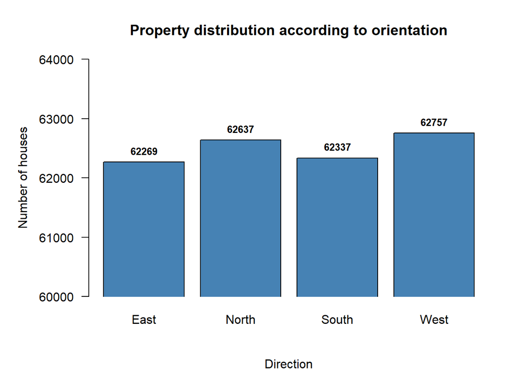

```r
#Counting of houses facing each Direction
facing_counts <- table(dt$Facing)
par(mar = c(5, 6, 4, 2),mgp = c(4, 1, 0))

bp1 = barplot(table(dt$Facing),
        main = "Property distribution according to orientation",
        col = "steelblue",
        xlab = "Direction",
        ylab = "Number of houses",  ylim= c(60000,64000),xpd = FALSE,
        las = 1)

text(x = bp1,
     y = facing_counts,
     labels = facing_counts,
     pos = 3, xpd = FALSE,
     cex = 0.8,
     font = 2)
```

```r
#The average prices of houses based on their facing direction
avg_price_summary <- dt %>%
  group_by(Facing) %>%
  summarise(Average_Price = mean(Price_in_Lakhs),
            Property_Count = n()) %>%
  arrange(desc(Average_Price))

print(avg_price_summary)
```

```
# A tibble: 4 × 3
  Facing Average_Price Property_Count
  <chr>          <dbl>          <int>
1 West            255.          62757
2 North           255.          62637
3 East            254.          62269
4 South           254.          62337
```

```r
# Generate frequency tables for all four directions
n_counts <- table(dt$Year_Built[dt$Facing == "North"])
s_counts <- table(dt$Year_Built[dt$Facing == "South"])
e_counts <- table(dt$Year_Built[dt$Facing == "East"])
w_counts <- table(dt$Year_Built[dt$Facing == "West"])


max_val <- max(c(n_counts, s_counts, e_counts, w_counts))


library(plotly)

plot_data <- dt %>%
  group_by(Year_Built, Facing) %>%
  summarise(Count = n(), .groups = 'drop')

# Creating the interactive plot
p <- plot_ly(plot_data,
             x = ~Year_Built,
             y = ~Count,
             color = ~Facing,
             colors = c("blue", "red", "darkgreen", "orange"),
             type = 'scatter',
             mode = 'lines+markers') %>%
  layout(title = "Year-wise property sales acc. to orientation",
         xaxis = list(title = "Year Built"),
         yaxis = list(title = "Number of houses sold", range = c(1700, max(plot_data$Count) + 100)),
         legend = list(title = list(text = 'Click to Toggle Direction')))

# Display the plot
p
```

[interactive chart not shown]

### 3.10 Age of Property

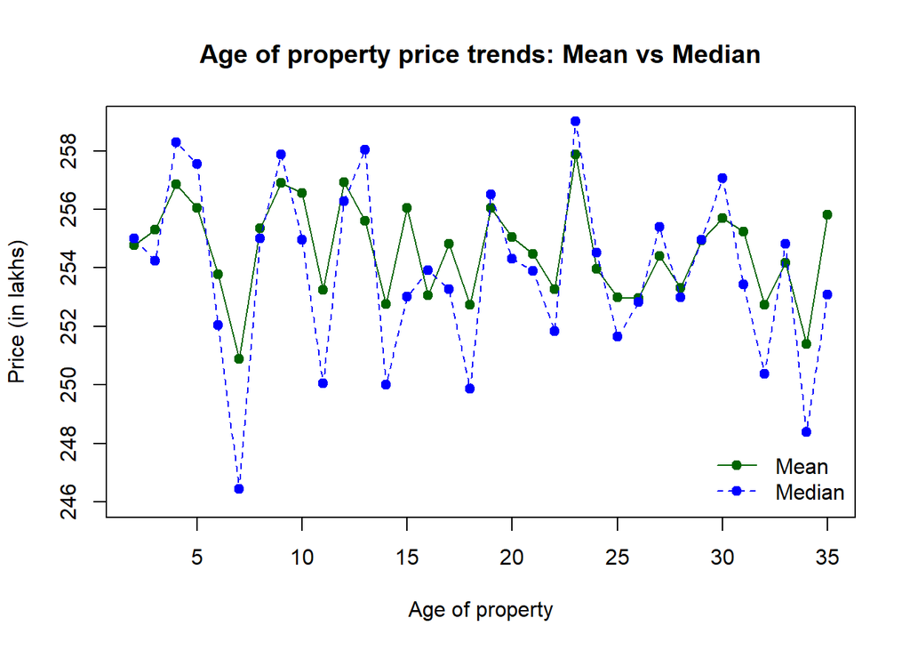

```r
# Calculate the age statistics
age_mean <- aggregate(Price_in_Lakhs ~ Age_of_Property, data = dt, FUN = mean)
age_min  <- aggregate(Price_in_Lakhs ~ Age_of_Property, data = dt, FUN = min)
age_max  <- aggregate(Price_in_Lakhs ~ Age_of_Property, data = dt, FUN = max)
age_median <- aggregate(Price_in_Lakhs ~ Age_of_Property, data = dt, FUN = median)

plot(age_mean$Age_of_Property, age_mean$Price_in_Lakhs,
     type = "o", lty = 1,
     pch = 19,
     col = "darkgreen",
     xlab = "Age of property",
     ylab = "Price (in lakhs)",ylim=c(246,259),
     main = "Age of property price trends: Mean vs Median")

lines(age_median$Age_of_Property, age_median$Price_in_Lakhs,
     type = "o", lty = 2,
     pch = 19,
     col = "blue")

#Legend
legend("bottomright",
       legend = c("Mean", "Median"),
       col = c("darkgreen", "blue"),
       lty = c(1, 2),
       pch = c(19, 19,19),
       bty = "n")
```

- There is no consistent trend showing that prices increase or decrease with the age of the property, suggesting that age alone does not explain the variation of price and more analysis is required.

### 3.11 Amenities

```r
# install.packages("fastDummies")
library(fastDummies)

# split by ", " to create individual columns
dt_expanded <- dummy_cols(dt,
                          select_columns = "Amenities",
                          split = ", ")

dt_expanded$Amenities <- NULL
```

Extended dataset created.

```r
# Identify our amenity columns
amenity_cols <- c("Amenities_Garden", "Amenities_Clubhouse",
                  "Amenities_Pool", "Amenities_Gym", "Amenities_Playground","Parking_Space","Security")

# Map "Yes" to 1 and "No" to 0
dt_expanded$Security <- ifelse(dt_expanded$Security == "Yes", 1, 0)
dt_expanded$Parking_Space <- ifelse(dt_expanded$Parking_Space == "Yes", 1, 0)

# Sum the columns to get the count of houses for each
amenity_counts <- colSums(dt_expanded[amenity_cols], na.rm = TRUE)

# summary table
amenity_summary <- data.frame(
  Amenity = names(amenity_counts),
  Count = as.numeric(amenity_counts),
  Percentage = round((as.numeric(amenity_counts) / nrow(dt_expanded)) * 100, 2)
)
print(amenity_summary)
```

```
               Amenity  Count Percentage
1     Amenities_Garden 150177      60.07
2  Amenities_Clubhouse 150059      60.02
3       Amenities_Pool 150096      60.04
4        Amenities_Gym 149960      59.98
5 Amenities_Playground 149780      59.91
6        Parking_Space 124544      49.82
7             Security 125233      50.09
```

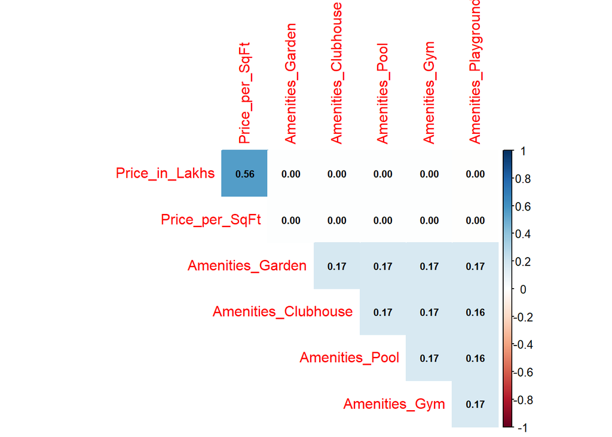

```r
# Amenity columns
cols_to_compare <- c("Price_in_Lakhs", "Price_per_SqFt",
                     "Amenities_Garden", "Amenities_Clubhouse",
                  "Amenities_Pool", "Amenities_Gym", "Amenities_Playground")

#  Calculate the matrix
cor_matrix <- cor(dt_expanded[cols_to_compare])

# Correlation Plot
corrplot::corrplot(cor_matrix,
         method = "color",
         addCoef.col = "black",
         number.cex = 0.7,
         type = "upper",
         diag = FALSE)
```

- Correlation between amenities and prices is 0 in most of the cases.

```r
#Price for houses with amenity pool versus those without it
amenity_stats_pool <- aggregate(Price_in_Lakhs ~ Amenities_Pool, data = dt_expanded,
                           FUN = function(x) c(Mean = mean(x),
                                               Median = median(x),
                                               SD = sd(x),
                                               Min = min(x),
                                               Max = max(x)))

# Convert to a readable data frame
amenity_stats_pool <- do.call(data.frame, amenity_stats_pool)
print(amenity_stats_pool)
```

```
  Amenities_Pool Price_in_Lakhs.Mean Price_in_Lakhs.Median Price_in_Lakhs.SD
1              0            254.2831               253.045          141.3782
2              1            254.7890               254.490          141.3312
  Price_in_Lakhs.Min Price_in_Lakhs.Max
1              10.00             499.99
2              10.01             500.00
```

- Presence of pool has little impact on our data.

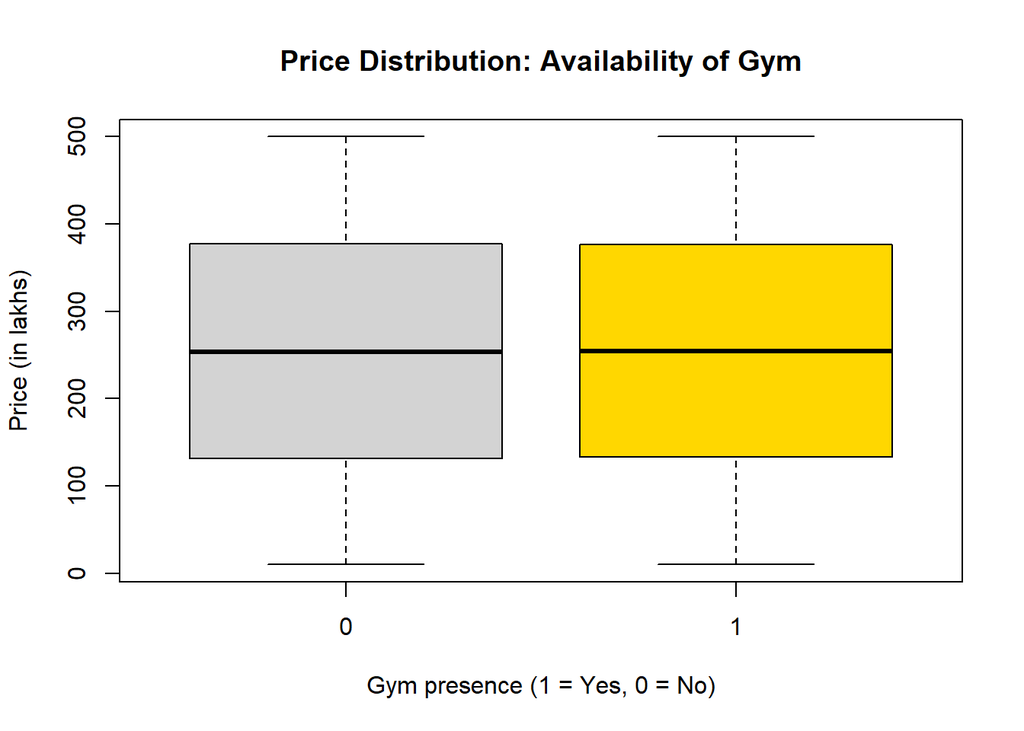

```r
# Visualizing the impact of having a Gym on Price
boxplot(Price_in_Lakhs ~ Amenities_Gym , data = dt_expanded,
        main = "Price Distribution: Availability of Gym",
        xlab = "Gym presence (1 = Yes, 0 = No)",
        ylab = "Price (in lakhs)",
        col = c("lightgrey", "gold"))
```

- We observe that the availability of gym also has little impact on the prices and so do the other amenities.

```r
calculate_premium <- function(amenity_name) {
  # Mean price with the amenity
  mean_with <- mean(dt_expanded$Price_in_Lakhs[dt_expanded[[amenity_name]] == 1], na.rm = TRUE)

  # Mean price without the amenity
  mean_without <- mean(dt_expanded$Price_in_Lakhs[dt_expanded[[amenity_name]] == 0], na.rm = TRUE)

  # Calculate Premium
  premium_val <- mean_with - mean_without
  premium_pct <- (premium_val / mean_without) * 100


  data.frame(
    Amenity = amenity_name,
    Avg_Price_With = round(mean_with, 2),
    Avg_Price_Without = round(mean_without, 2),
    Premium_Lakhs = round(premium_val, 2),
    Premium_Percent = round(premium_pct, 2)
  )
}


premium_table <- do.call(rbind, lapply(amenity_cols, calculate_premium))


premium_table <- premium_table[order(-premium_table$Premium_Percent), ]

print(premium_table)
```

```
               Amenity Avg_Price_With Avg_Price_Without Premium_Lakhs
7             Security         255.12            254.05          1.08
4        Amenities_Gym         254.81            254.25          0.56
3       Amenities_Pool         254.79            254.28          0.51
6        Parking_Space         254.75            254.43          0.32
2  Amenities_Clubhouse         254.66            254.48          0.18
1     Amenities_Garden         254.64            254.50          0.14
5 Amenities_Playground         254.38            254.90         -0.52
  Premium_Percent
7            0.42
4            0.22
3            0.20
6            0.12
2            0.07
1            0.05
5           -0.21
```

- We can observe that the presence of amenities affect the prices very little. But Playground has negative premium.

### 3.12 City

```r
#State wise city count
State_summary <- dt %>%
  group_by(State) %>%
      summarize(Cities = paste(unique(City), collapse = ", "),
                no_cities = length(unique(City)))
```

```r
# Calculate average price per city
city_summary <- dt %>%
  group_by(City) %>%
  summarise(
    Avg_Price_Lakhs = mean(Price_in_Lakhs, na.rm = TRUE),
    Property_Count = n()
  )

print(city_summary)
```

```
# A tibble: 42 × 3
   City        Avg_Price_Lakhs Property_Count
   <chr>                 <dbl>          <int>
 1 Ahmedabad              254.           6411
 2 Amritsar               252.           6221
 3 Bangalore              258.           4144
 4 Bhopal                 256.           6284
 5 Bhubaneswar            255.           6323
 6 Bilaspur               252.           6263
 7 Chennai                257.           6168
 8 Coimbatore             257.           6461
 9 Cuttack                251.           6358
10 Dehradun               257.           6234
# ℹ 32 more rows
```

```r
library(tidygeocoder)

# For finding the Lat/Long for each city automatically
city_geo <- city_summary %>%
  geocode(city = City, method = 'osm', lat = latitude , long = longitude)

#BY default Geocode treats Vishakhapatnam as Vizag and Dwarka as
# the ancient city  of Gujrat
# Manually update Visakhapatnam and Dwarka coordinates in city_geo dataframe
city_geo <- city_geo %>%
  mutate(
    latitude = case_when(
      City == "Dwarka" ~ 28.5823,
      City == "Vishakhapatnam" ~ 17.6868,
      TRUE ~ latitude
    ),
    longitude = case_when(
      City == "Dwarka" ~ 77.0500,
      City == "Vishakhapatnam" ~ 83.2185,
      TRUE ~ longitude
    )
  )

#Creating interactive Map
library(leaflet)

pal <- colorNumeric(
  palette = "RdYlGn",
  domain = city_geo$Avg_Price_Lakhs,
  reverse = TRUE
)

leaflet(city_geo) %>%
  addTiles() %>%
  addCircleMarkers(
    lng = ~longitude,
    lat = ~latitude,
    radius = 5,
    weight = 1,
    fillOpacity = 0.8,
    color = "white",
    fillColor = ~pal(Avg_Price_Lakhs),
    popup = ~paste0("<b>City:</b> ", City,
                    "<br><b>Avg Price:</b> ", round(Avg_Price_Lakhs, 2), " Lakhs",
                    "<br><b>Total Properties:</b> ", Property_Count),
    clusterOptions = markerClusterOptions()
  ) %>%
  # Add a legend to make the colors clear
  addLegend(
    pal = pal,
    values = ~Avg_Price_Lakhs,
    opacity = 0.7,
    title = "Avg House Price (Lakhs)",
    position = "bottomright"
  )
```

[interactive chart not shown]

```r
# Calculate average price per city
city_summary <- dt %>%
  group_by(City) %>%
  summarise(
    Median_Price_Lakhs = median(Price_in_Lakhs, na.rm = TRUE),
    Avg_Price_Lakhs = mean(Price_in_Lakhs, na.rm = TRUE),
    Property_Count = n(),
    # Calculate percentages for each direction
    Pct_North = round(mean(Facing == "North", na.rm = TRUE) * 100, 1),
    Pct_South = round(mean(Facing == "South", na.rm = TRUE) * 100, 1),
    Pct_East  = round(mean(Facing == "East", na.rm = TRUE) * 100, 1),
    Pct_West  = round(mean(Facing == "West", na.rm = TRUE) * 100, 1)
  )

city_geo$Median_Price_Lakhs = city_summary$Median_Price_Lakhs
city_geo <- city_geo %>%
  select(City, latitude, longitude,) %>% # Keep only geo columns from the old city_geo
  left_join(city_summary, by = "City")

#Creating interactive Map
library(leaflet)

pal <- colorNumeric(
  palette = "RdYlGn",
  domain = city_geo$Median_Price_Lakhs,
  reverse = TRUE
)

leaflet(city_geo) %>%
  addTiles() %>%
  addCircleMarkers(
    lng = ~longitude,
    lat = ~latitude,
    radius = 5,
    weight = 1,
    fillOpacity = 0.8,
    color = "white",
    fillColor = ~pal(Median_Price_Lakhs),
    popup = ~paste0("<b>City:</b> ", City,
                    "<br><b>Median Price:</b> ", round(Median_Price_Lakhs, 2),
                    " Lakhs","<br><b>Total Properties:</b> ", Property_Count,
      "<hr style='margin: 5px 0;'>",
      "<b>Orientation Distribution:</b><br>",
      "North: ", Pct_North, "% | South: ", Pct_South, "%<br>",
      "East: ", Pct_East, "% | West: ", Pct_West, "%"),
    clusterOptions = markerClusterOptions()
  ) %>%
  # Add a legend to make the colors clear
  addLegend(
    pal = pal,
    values = ~Median_Price_Lakhs,
    opacity = 0.7,
    title = "Median House Price (Lakhs)",
    position = "bottomright"
  )
```

[interactive chart not shown]

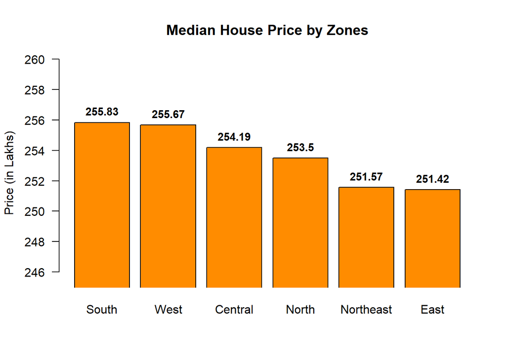

```r
#Zone Wise Data

library(dplyr)

dt_zoned <- dt %>%
  mutate(Zone = case_when(
    City %in% c("New Delhi", "Ludhiana", "Jaipur", "Jodhpur", "Lucknow",
                "Dehradun", "Noida", "Faridabad", "Amritsar", "Haridwar",
                "Gurgaon","Dwarka") ~ "North",

    City %in% c("Chennai", "Coimbatore", "Bangalore", "Warangal", "Hyderabad",
                "Vishakhapatnam", "Mysore", "Vijayawada", "Trivandrum",
                "Kochi", "Mangalore") ~ "South",

    City %in% c("Mumbai", "Pune", "Nagpur", "Ahmedabad", "Surat") ~ "West",

    City %in% c("Kolkata", "Ranchi", "Durgapur", "Gaya", "Jamshedpur",
                "Patna", "Cuttack", "Bhubaneswar") ~ "East",

    City %in% c("Bhopal", "Indore", "Raipur", "Bilaspur") ~ "Central",

    City %in% c("Guwahati", "Silchar") ~ "Northeast",

    TRUE ~ "Other"
  ))

zone_summary <- dt_zoned %>%
  group_by(Zone) %>%
  summarise(
    Median_Price_Lakhs = median(Price_in_Lakhs, na.rm = TRUE),
    House_Count = n()
  ) %>%
  arrange(desc(Median_Price_Lakhs))


bp = barplot(zone_summary$Median_Price_Lakhs,
        names.arg = zone_summary$Zone,
        col = "darkorange",
        main = "Median House Price by Zones",
        ylab = "Price (in Lakhs)",
        las = 1, xpd = FALSE,
        ylim = c(245, 260))



text(x = bp,
     y = zone_summary$Median_Price_Lakhs,
     labels = round(zone_summary$Median_Price_Lakhs, 2),
     pos = 3,
     cex = 0.9, xpd = FALSE,
     font = 2,
     col = "black")
```

### 3.13 States with the Most Affordable Housing

```r
state_summary <- dt %>%
  group_by(State) %>%
  summarise(
    Median_Price_Lakhs = median(Price_in_Lakhs, na.rm = TRUE),
    Avg_Price_Lakhs = mean(Price_in_Lakhs, na.rm = TRUE),
    Property_Count = n()
  )%>% arrange(Median_Price_Lakhs)
state_summary
```

```
# A tibble: 20 × 4
   State          Median_Price_Lakhs Avg_Price_Lakhs Property_Count
   <chr>                       <dbl>           <dbl>          <int>
 1 Delhi                        250.            253.          12552
 2 Punjab                       251.            253.          12516
 3 West Bengal                  251.            254.          12622
 4 Odisha                       251.            253.          12681
 5 Jharkhand                    252.            254.          12480
 6 Assam                        252.            253.          12496
 7 Rajasthan                    252.            255.          12402
 8 Chhattisgarh                 252.            253.          12456
 9 Bihar                        252.            255.          12369
10 Kerala                       254.            254.          12487
11 Maharashtra                  255.            255.          12533
12 Telangana                    255.            256.          12539
13 Uttarakhand                  255.            255.          12501
14 Haryana                      255.            254.          12314
15 Andhra Pradesh               256.            255.          12462
16 Madhya Pradesh               256.            256.          12451
17 Tamil Nadu                   256.            257.          12629
18 Gujarat                      257.            256.          12578
19 Uttar Pradesh                257.            256.          12508
20 Karnataka                    258.            257.          12424
```

- States appearing at the top of the list offer comparatively more affordable housing options, while states toward the bottom exhibit higher average prices, often associated with stronger urban demand.

### 3.14 Schools

```r
cor(dt_expanded$Price_in_Lakhs, dt_expanded$Nearby_Schools)
```

```
[1] 0.0001549054
```

```r
cor(dt_expanded$Price_in_Lakhs, dt_expanded$Nearby_Hospitals)
```

```
[1] -0.002769148
```

### 3.15 Floors

```r
cor(dt$Floor_No,dt$Total_Floors)
```

```
[1] 0.001168596
```

- We can observe that floor no. and total no. of floors have significantly low correlation.

### 3.16 Locality wise grouping

```r
locality_luxury <- dt %>%
  group_by(Locality, City) %>%
  summarise(
    Avg_Price = mean(Price_in_Lakhs, na.rm = TRUE),
    Median_Price = median(Price_in_Lakhs),
    Sample_Size = n()
  ) %>%
  arrange(desc(Median_Price))

print(locality_luxury)
```

```
# A tibble: 20,999 × 5
# Groups:   Locality [500]
   Locality     City      Avg_Price Median_Price Sample_Size
   <chr>        <chr>         <dbl>        <dbl>       <int>
 1 Locality_335 Bangalore      407.         493.           5
 2 Locality_350 Mumbai         492.         492.           1
 3 Locality_407 Bangalore      422.         489.           5
 4 Locality_138 Bangalore      403.         488.           3
 5 Locality_42  Mysore         480.         480.           2
 6 Locality_129 Pune           476.         476.           2
 7 Locality_329 Raipur         356.         472.           7
 8 Locality_77  Mangalore      465.         470.           3
 9 Locality_427 Indore         353.         468.          11
10 Locality_8   Silchar        404.         467.           6
# ℹ 20,989 more rows
```

```r
locality_to_join <- locality_luxury %>%
  select(Locality, City, Median_Price_Locality = Median_Price)

dt_expanded <- dt_expanded %>%
  left_join(locality_to_join, by = c("Locality", "City"))

#Confirming that there are no missing values.
sum(is.na(dt_expanded$Median_Price_Locality))
```

```
[1] 0
```

## 4 Hypothesis Testing

### 4.1 Research Statement: The prices of villas are generally higher than the apartments.

- **NULL HYPOTHESIS**:- The average prices of the apartments are equal to the average prices of the villas.
- **ALTERNATIVE HYPOTHESIS**:- The average prices of the villas are higher than the average prices of the apartments.
- **H0:** mean_price_of_villa = mean_price_of_apartment
- **H1:** mean _price_of_villa > mean_price_of_apartment

  ```r
  villa <- dt$Price_in_Lakhs[dt$Property_Type == "Villa"]
  apartment <- dt$Price_in_Lakhs[dt$Property_Type == "Apartment"]
  t.test(villa, apartment, alternative = "greater")
  ```

  ```
      Welch Two Sample t-test

  data:  villa and apartment
  t = -1.2317, df = 166668, p-value = 0.891
  alternative hypothesis: true difference in means is greater than 0
  95 percent confidence interval:
   -1.992864       Inf
  sample estimates:
  mean of x mean of y
   253.7688  254.6221
  ```

**Interpretation**:-

At the 5% significance level, we fail to reject the null hypothesis (p > 0.05). There is insufficient statistical evidence to conclude that villas are more expensive than apartments. In fact, the sample means indicate that apartment prices are slightly higher than villa prices in this data-set.

```r
var.test(villa, apartment)
```

```
    F test to compare two variances

data:  villa and apartment
F = 0.9921, num df = 83743, denom df = 82955, p-value = 0.2522
alternative hypothesis: true ratio of variances is not equal to 1
95 percent confidence interval:
 0.9787197 1.0056620
sample estimates:
ratio of variances
         0.9920996
```

- Based on the output of the **F-test to compare two variances** for villas and apartments, we got that there is no statistically significant difference between the variance of villa prices and apartment prices in our data-set.
- The F-statistic very close to 1 (**F = 0.9921**) suggests that the variances are almost identical.

### 4.2 Research Statement :- Do Furnished homes have more cost than the Unfurnished homes ?

- **NULL HYPOTHESIS**:- The furnished and unfurnished houses have the same price.
- **ALTERNATIVE HYPOTHESIS**:- The furnished houses have higher prices than the unfurnished houses

  ```r
  furnished <- dt$Price_in_Lakhs[dt$Furnished_Status == "Furnished"]
  unfurnished <- dt$Price_in_Lakhs[dt$Furnished_Status == "Unfurnished"]
  t.test(furnished, unfurnished, alternative = "greater")
  ```

  ```
      Welch Two Sample t-test

  data:  furnished and unfurnished
  t = -0.77162, df = 166624, p-value = 0.7798
  alternative hypothesis: true difference in means is greater than 0
  95 percent confidence interval:
   -1.672957       Inf
  sample estimates:
  mean of x mean of y
   254.4455  254.9798
  ```

**Interpretation:**

At the 5% significance level, we fail to reject the null hypothesis (p > 0.05). There is insufficient statistical evidence to conclude that furnished homes have more cost than the unfurnished homes. In fact, the sample means indicate that prices of the unfurnished homes are slightly higher than prices of the furnished homes in this data-set.

## 5 Feature Engineering

```r
names(Filter(is.character, dt_expanded))
```

```
[1] "State"                          "City"
[3] "Locality"                       "Property_Type"
[5] "Furnished_Status"               "Public_Transport_Accessibility"
[7] "Facing"                         "Owner_Type"
[9] "Availability_Status"
```

```r
#Columns: Property_Type,Furnished_Status,Facing, Owner_Type, Availability_Status.
dt_expanded <- dummy_cols(dt_expanded,
                          select_columns =c( "Property_Type","Furnished_Status"
                                             ,"Facing","Owner_Type",
                                             "Availability_Status"),
                          remove_selected_columns = TRUE,
                          remove_first_dummy = TRUE)


#Column: Public_Transport_Accessibility.
dt_expanded <- dt_expanded %>%
  mutate(Public_Transport_Accessibility = case_when(
    Public_Transport_Accessibility == "Low" ~ 0,
    Public_Transport_Accessibility == "Medium" ~ 1,
    Public_Transport_Accessibility == "High" ~ 2
  ))
```

- Now our Data is ready for Modelling.

  ```r
  #Preventing data loss
  dtm = dt_expanded
  ```

## 6 Model Training

```r
#Checking for missing values
sum(is.na(dtm))
```

```
[1] 0
```

- Our data has no missing value.

```r
library(dplyr)
library(car)

# Create the modeling dataset by dropping non-numeric and redundant columns
X_model <- dtm %>%
  dplyr::select(
    -ID, -State, -City, -Locality,   # Character columns
    -Year_Built
  )
```

### 6.1 Multicollinearity Check

```r
#  Build a preliminary model
prelim_model <- lm(Price_in_Lakhs ~ ., data = X_model)

#  Calculate VIF
vif_results <- data.frame(VIF = vif(prelim_model)) %>%
  tibble::rownames_to_column("Feature")%>%
  arrange(desc(VIF))

print(head(vif_results,5))
```

```
         Feature      VIF
1 Price_per_SqFt 1.662109
2   Size_in_SqFt 1.626885
3    Facing_West 1.503924
4   Facing_North 1.503520
5   Facing_South 1.502251
```

- VIF values of all columns are <5; which signifies that the columns are not linearly dependent.

### 6.2 Multiple Linear regression

```r
library(caret)


set.seed(36)
trainIndex <- createDataPartition(X_model$Price_in_Lakhs, p = 0.75, list = FALSE)
train_data <- X_model[trainIndex, ]
test_data  <- X_model[-trainIndex, ]


lm1 <- lm(Price_in_Lakhs ~ ., data = train_data)


summary(lm1)
```

```
Call:
lm(formula = Price_in_Lakhs ~ ., data = train_data)

Residuals:
    Min      1Q  Median      3Q     Max
-470.43  -62.23    1.12   71.95  246.02

Coefficients:
                                         Estimate Std. Error t value Pr(>|t|)
(Intercept)                            -9.903e+01  1.851e+00 -53.506   <2e-16
BHK                                    -9.506e-02  1.612e-01  -0.590   0.5555
Size_in_SqFt                            5.729e-02  2.241e-04 255.625   <2e-16
Price_per_SqFt                          9.307e+02  2.254e+00 413.007   <2e-16
Floor_No                                1.689e-02  2.551e-02   0.662   0.5080
Total_Floors                           -1.871e-02  2.629e-02  -0.712   0.4767
Age_of_Property                        -1.730e-02  2.328e-02  -0.743   0.4574
Nearby_Schools                         -1.940e-02  7.930e-02  -0.245   0.8068
Nearby_Hospitals                       -1.005e-01  7.953e-02  -1.263   0.2065
Public_Transport_Accessibility          2.059e-01  2.794e-01   0.737   0.4612
Parking_Space                           3.279e-01  4.565e-01   0.718   0.4725
Security                                1.164e+00  4.564e-01   2.550   0.0108
Amenities_Clubhouse                     5.625e-02  4.843e-01   0.116   0.9075
Amenities_Garden                        1.290e-01  4.851e-01   0.266   0.7903
Amenities_Gym                           6.297e-01  4.846e-01   1.299   0.1938
Amenities_Playground                   -2.472e-01  4.838e-01  -0.511   0.6094
Amenities_Pool                          1.444e-01  4.845e-01   0.298   0.7656
Median_Price_Locality                   2.931e-01  3.621e-03  80.943   <2e-16
`Property_Type_Independent House`       7.257e-01  5.595e-01   1.297   0.1946
Property_Type_Villa                    -1.171e+00  5.592e-01  -2.095   0.0362
`Furnished_Status_Semi-furnished`      -3.460e-01  5.590e-01  -0.619   0.5359
Furnished_Status_Unfurnished            6.808e-01  5.589e-01   1.218   0.2232
Facing_North                           -2.209e-01  6.460e-01  -0.342   0.7324
Facing_South                           -7.922e-01  6.473e-01  -1.224   0.2210
Facing_West                            -2.765e-01  6.455e-01  -0.428   0.6684
Owner_Type_Builder                      5.248e-01  5.586e-01   0.940   0.3474
Owner_Type_Owner                        4.933e-01  5.591e-01   0.882   0.3776
Availability_Status_Under_Construction -5.568e-02  4.565e-01  -0.122   0.9029

(Intercept)                            ***
BHK
```

[output cut: 17 more lines]

```
Property_Type_Villa                    *
`Furnished_Status_Semi-furnished`
Furnished_Status_Unfurnished
Facing_North
Facing_South
Facing_West
Owner_Type_Builder
Owner_Type_Owner
Availability_Status_Under_Construction
---
Signif. codes:  0 '***' 0.001 '**' 0.01 '*' 0.05 '.' 0.1 ' ' 1

Residual standard error: 98.82 on 187473 degrees of freedom
Multiple R-squared:  0.5111,    Adjusted R-squared:  0.5111
F-statistic:  7260 on 27 and 187473 DF,  p-value: < 2.2e-16
```

```r
lm2 <- lm(Price_in_Lakhs ~ Median_Price_Locality+Size_in_SqFt+Price_per_SqFt+Security+Property_Type_Villa , data = train_data)

summary(lm2)
```

```
Call:
lm(formula = Price_in_Lakhs ~ Median_Price_Locality + Size_in_SqFt +
    Price_per_SqFt + Security + Property_Type_Villa, data = train_data)

Residuals:
    Min      1Q  Median      3Q     Max
-469.50  -62.23    1.13   71.94  245.70

Coefficients:
                        Estimate Std. Error t value Pr(>|t|)
(Intercept)           -9.907e+01  1.201e+00 -82.457  < 2e-16 ***
Median_Price_Locality  2.930e-01  3.620e-03  80.943  < 2e-16 ***
Size_in_SqFt           5.729e-02  2.241e-04 255.652  < 2e-16 ***
Price_per_SqFt         9.308e+02  2.253e+00 413.043  < 2e-16 ***
Security               1.168e+00  4.564e-01   2.559  0.01051 *
Property_Type_Villa   -1.536e+00  4.837e-01  -3.176  0.00149 **
---
Signif. codes:  0 '***' 0.001 '**' 0.01 '*' 0.05 '.' 0.1 ' ' 1

Residual standard error: 98.82 on 187495 degrees of freedom
Multiple R-squared:  0.5111,    Adjusted R-squared:  0.5111
F-statistic: 3.92e+04 on 5 and 187495 DF,  p-value: < 2.2e-16
```

- We tried multiple Test-train ratios (ratio = 0.7, 0.75, 0.8, 0.9). Among them the **Average Multiple R-squared value** is 0.5103. It means **around 51% variations in the data can be explained on the basis of this Multiple Linear Regression Model.**

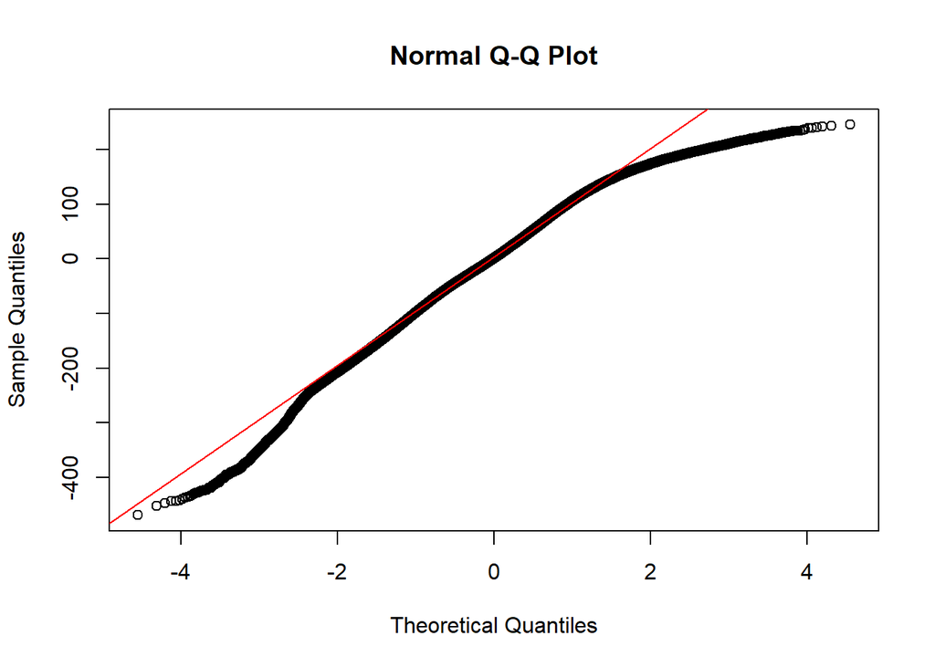

```r
#Checking Normal Q-Q Plot to find model's errors follow a normal distribution or not.
qqnorm(lm2$residuals)
qqline(lm2$residuals, col="red")
```

- The points follow the red diagonal line in the middle but **“bow” significantly at both ends** (the tails).
- **Verdict**: This “S-shape” suggests that our data has a skewed distribution which a standard linear model isn’t fully accounting for.

### 6.3 Generalized Linear Model

```r
set.seed(36)
trainIndex <- createDataPartition(X_model$Price_in_Lakhs, p = 0.75, list = FALSE)
train_data <- X_model[trainIndex, ]
test_data  <- X_model[-trainIndex, ]

lm2 <- lm(Price_in_Lakhs ~ Median_Price_Locality+Size_in_SqFt+Price_per_SqFt+Security+Property_Type_Villa , data = train_data)

# GLM with Gamma distribution and Log Link
glm1 <- glm(Price_in_Lakhs ~ Median_Price_Locality+Size_in_SqFt+Price_per_SqFt+Property_Type_Villa,
                 family = Gamma(link = "log"),
                 data = train_data)
summary(glm1)
```

```
Call:
glm(formula = Price_in_Lakhs ~ Median_Price_Locality + Size_in_SqFt +
    Price_per_SqFt + Property_Type_Villa, family = Gamma(link = "log"),
    data = train_data)

Coefficients:
                        Estimate Std. Error t value Pr(>|t|)
(Intercept)            3.522e+00  5.075e-03 693.862  < 2e-16 ***
Median_Price_Locality  1.139e-03  1.558e-05  73.117  < 2e-16 ***
Size_in_SqFt           3.352e-04  9.643e-07 347.637  < 2e-16 ***
Price_per_SqFt         5.405e+00  9.697e-03 557.396  < 2e-16 ***
Property_Type_Villa   -5.459e-03  2.082e-03  -2.623  0.00872 **
---
Signif. codes:  0 '***' 0.001 '**' 0.01 '*' 0.05 '.' 0.1 ' ' 1

(Dispersion parameter for Gamma family taken to be 0.18081)

    Null deviance: 92288  on 187500  degrees of freedom
Residual deviance: 53825  on 187496  degrees of freedom
AIC: 2292187

Number of Fisher Scoring iterations: 12
```

```r
# Comparing the AIC (Lower is better)
AIC(lm2)
```

```
[1] 2254604
```

```r
AIC(glm1)
```

```
[1] 2292187
```

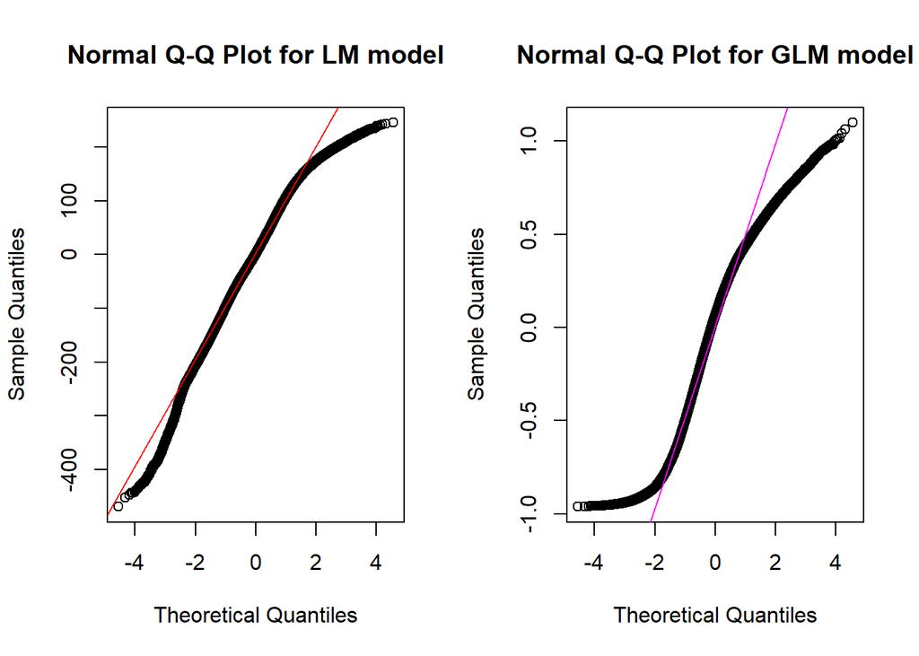

```r
par(mfrow = c(1,2))
qqnorm(lm2$residuals,main = "Normal Q-Q Plot for LM model")
qqline(lm2$residuals, col="red")
qqnorm(glm1$residuals,main = "Normal Q-Q Plot for GLM model")
qqline(glm1$residuals, col="magenta")
```

```r
# Predict using both models on our test data
pred_lm  <- predict(lm2, newdata = test_data)
pred_glm <- predict(glm1, newdata = test_data, type = "response")

# Calculate Root Mean Squared Error (RMSE)
rmse_lm  <- sqrt(mean((test_data$Price_in_Lakhs - pred_lm)^2))
rmse_glm <- sqrt(mean((test_data$Price_in_Lakhs - pred_glm)^2))

# RMSE
cat("LM RMSE:", rmse_lm, "Lakhs\n")
```

```
LM RMSE: 99.0472 Lakhs
```

```r
cat("GLM RMSE:", rmse_glm, "Lakhs")
```

```
GLM RMSE: 422.2565 Lakhs
```

```r
# Calculate Mean Absolute Error (MAE)
mae_lm  <- mean(abs(test_data$Price_in_Lakhs - pred_lm))
mae_glm <- mean(abs(test_data$Price_in_Lakhs - pred_glm))

cat("LM MAE:", mae_lm, "\n")
```

```
LM MAE: 79.15163
```

```r
cat("GLM MAE:", mae_glm)
```

```
GLM MAE: 128.9541
```

### 6.4 Decision Tree

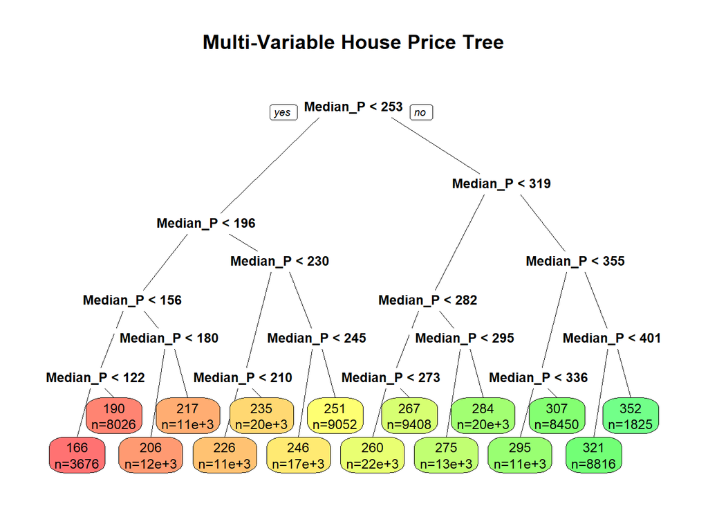

```r
library(rpart)
library(rpart.plot)

tree_model <- rpart(Price_in_Lakhs ~ Median_Price_Locality + Size_in_SqFt +
                    Security + Property_Type_Villa,
                    data = train_data,
                    method = "anova",
                    control = rpart.control(cp = 0.00001, maxdepth = 4))


prp(tree_model, extra = 1, box.palette = "RdYlGn", main = "Multi-Variable House Price Tree")
```

- The model has determined that **Median_Price_Locality** is so dominant that it has used it for every single split in the tree, completely ignoring Size, Security, and Property Type for now.

```r
#Extract importance scores
importance_scores <- tree_model$variable.importance


library(dplyr)

import_df <- data.frame(Importance = importance_scores) %>%
  tibble::rownames_to_column("Feature") %>%
  mutate(Percentage = (Importance / sum(Importance)) * 100) %>%
  arrange(desc(Percentage))
import_df
```

```
                Feature  Importance  Percentage
1 Median_Price_Locality 247317971.1 99.94773137
2          Size_in_SqFt    129337.3  0.05226863
```

- Our Variable Importance analysis reveals that ‘Location’ is the primary determinant of property value in our dataset, accounting for over 99.9% of the model’s predictive power. While physical attributes like ‘Size’ are traditionally important, the sheer variance in price between different Indian localities makes the specific neighborhood the only statistically significant predictor for our current decision tree.

```r
# Predict on Test Data
pred_tree <- predict(tree_model, newdata = test_data)

# Calculate Errors
rmse_tree <- sqrt(mean((test_data$Price_in_Lakhs - pred_tree)^2))
mae_tree  <- mean(abs(test_data$Price_in_Lakhs - pred_tree))

cat("Decision Tree MAE:", mae_tree, "Lakhs\n")
```

```
Decision Tree MAE: 115.2747 Lakhs
```

```r
cat("Decision Tree RMSE:", rmse_tree, "Lakhs")
```

```
Decision Tree RMSE: 136.7141 Lakhs
```

- The **Decision Tree** highlights that location is the absolute driver of value, with **Median_Price_Locality** holding a **99.94% importance score**. While its higher **MAE of 115.27 Lakhs** shows it is currently less precise for individual predictions than our Linear Model.

### 6.5 Random Forest

- Since our **RMSE** and **MAE** results revealed that luxury outliers and non-linear patterns are challenging for our **LM** and **GLM**, a **Random Forest** is the natural evolution for our project. It builds hundreds of decision trees and averages them, which should significantly reduce the high errors.

```r
library(randomForest)

set.seed(12)
train_sample <- train_data[sample(1:nrow(train_data), 30000), ]


rf_model <- randomForest(Price_in_Lakhs ~ Median_Price_Locality + Size_in_SqFt +
                         Security + Property_Type_Villa,
                         data = train_sample,
                         ntree = 400,
                         importance = TRUE)


pred_rf <- predict(rf_model, newdata = test_data)
rmse_rf <- sqrt(mean((test_data$Price_in_Lakhs - pred_rf)^2))
mae_rf  <- mean(abs(test_data$Price_in_Lakhs - pred_rf))

cat("Random Forest MAE:", mae_rf, "Lakhs\n")
```

```
Random Forest MAE: 118.2085 Lakhs
```

```r
cat("Random Forest RMSE:", rmse_rf, "Lakhs")
```

```
Random Forest RMSE: 137.9692 Lakhs
```

- The **Linear Model (LM)** is the most effective tool for this dataset, achieving the lowest average error with a **Mean Absolute Error (MAE) of 79.15 Lakhs**. While more complex models like the **GLM** and **Random Forest** were explored, the LM’s ability to provide stable predictions across the price spectrum makes it the most reliable “calculator” for our final results.

## 7 Interactive Market Explorer

Now that we have established that **Locality** is the primary driver of house prices (99.94% importance), you can explore the data yourself using our interactive dashboard. Use the filters below to see how different BHK types and localities compare in real-time.

Link: https://atreyaghoshal.shinyapps.io/indian_housing_shiny/

## 8 Conclusion

- This study analysed housing prices in India using various statistical techniques in R.
- Data-driven approaches can effectively capture trends in housing prices and provide valuable insights for buyers, sellers, and policymakers.
- The results of our analysis suggest that the data may not be entirely authentic and may have been subject to manipulation.

### 8.1 Future Work

  Analysis is limited by data quality and lack of temporal depth. Future work could incorporate additional economic and demographic variables to improve predictive accuracy.